# Risk Factor Analysis

## Outcome Variable

**Outcome Variable:** sstunted

## Predictor Variables

**Intervention Variable:** fage

**Adjustment Set:**

unadjusted

## Stratifying Variables

The analysis was stratified on these variable(s):

- agecat
- studyid

The following strata were considered:

- agecat: 12 months, studyid: ki0047075b-MAL-ED
- agecat: 12 months, studyid: ki1000304b-SAS-FoodSuppl
- agecat: 12 months, studyid: ki1135781-COHORTS
- agecat: 12 months, studyid: ki1148112-LCNI-5
- agecat: 18 months, studyid: ki0047075b-MAL-ED
- agecat: 18 months, studyid: ki1000304b-SAS-FoodSuppl
- agecat: 18 months, studyid: ki1135781-COHORTS
- agecat: 18 months, studyid: ki1148112-LCNI-5
- agecat: 24 months, studyid: ki0047075b-MAL-ED
- agecat: 24 months, studyid: ki1135781-COHORTS
- agecat: 24 months, studyid: ki1148112-LCNI-5
- agecat: 3 months, studyid: ki0047075b-MAL-ED
- agecat: 3 months, studyid: ki1000304b-SAS-FoodSuppl
- agecat: 3 months, studyid: ki1135781-COHORTS
- agecat: 6 months, studyid: ki0047075b-MAL-ED
- agecat: 6 months, studyid: ki1000304b-SAS-FoodSuppl
- agecat: 6 months, studyid: ki1135781-COHORTS
- agecat: 6 months, studyid: ki1148112-LCNI-5
- agecat: 9 months, studyid: ki0047075b-MAL-ED
- agecat: 9 months, studyid: ki1000304b-SAS-FoodSuppl
- agecat: 9 months, studyid: ki1135781-COHORTS
- agecat: 9 months, studyid: ki1148112-LCNI-5
- agecat: Birth, studyid: ki0047075b-MAL-ED
- agecat: Birth, studyid: ki1135781-COHORTS

### Dropped Strata

Some strata were dropped due to rare outcomes:

- agecat: Birth, studyid: ki0047075b-MAL-ED
- agecat: 3 months, studyid: ki0047075b-MAL-ED
- agecat: 3 months, studyid: ki1000304b-SAS-FoodSuppl
- agecat: 6 months, studyid: ki0047075b-MAL-ED
- agecat: 6 months, studyid: ki1000304b-SAS-FoodSuppl
- agecat: 6 months, studyid: ki1148112-LCNI-5
- agecat: 9 months, studyid: ki0047075b-MAL-ED
- agecat: 9 months, studyid: ki1000304b-SAS-FoodSuppl
- agecat: 9 months, studyid: ki1148112-LCNI-5
- agecat: 12 months, studyid: ki0047075b-MAL-ED
- agecat: 12 months, studyid: ki1148112-LCNI-5
- agecat: 18 months, studyid: ki0047075b-MAL-ED
- agecat: 18 months, studyid: ki1148112-LCNI-5
- agecat: 24 months, studyid: ki0047075b-MAL-ED
- agecat: 24 months, studyid: ki1148112-LCNI-5

## Methods Detail

We’re interested in the causal parameters $E[Y_a]$ for all values of $a \in \mathcal{A}$. These parameters represent the mean outcome if, possibly contrary to fact, we intervened to set all units to have $A=a$. Under the randomization and positivity assumptions, these are identified by the statistical parameters $\psi_a=E_W[E_{Y|A,W}(Y|A=a,W)]$. In addition, we’re interested in the mean of $Y$, $E[Y]$ under no intervention (the observed mean). We will estimate these parameters by using SuperLearner to fit the relevant likelihood factors – $E_{Y|A,W}(Y|A=a,W)$ and $p(A=a|W)$, and then updating our likelihood fit using a joint TMLE.

For unadjusted analyses ($W=\{\}$), initial likelihoods were estimated using Lrnr_glm to estimate the simple $E(Y|A)$ and Lrnr_mean to estimate $p(A)$. For adjusted analyses, a small library containing Lrnr_glmnet, Lrnr_xgboost, and Lrnr_mean was used.

Having estimated these parameters, we will then use the delta method to estimate relative risks and attributable risks relative to a prespecified baseline level of $A$.

# Results Detail

## Results Plots

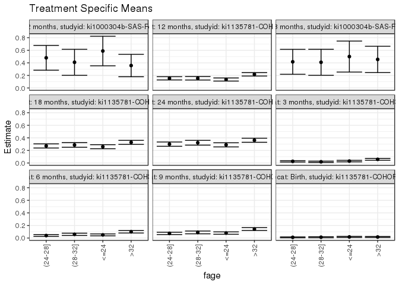

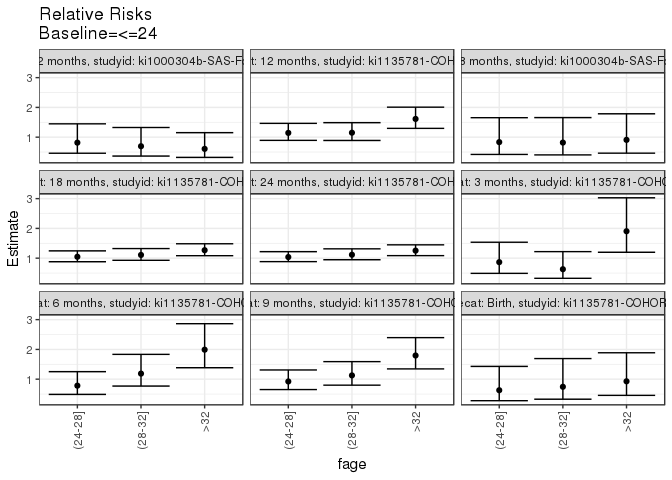

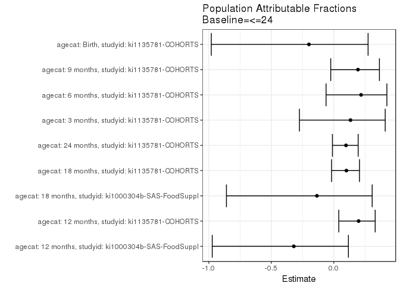

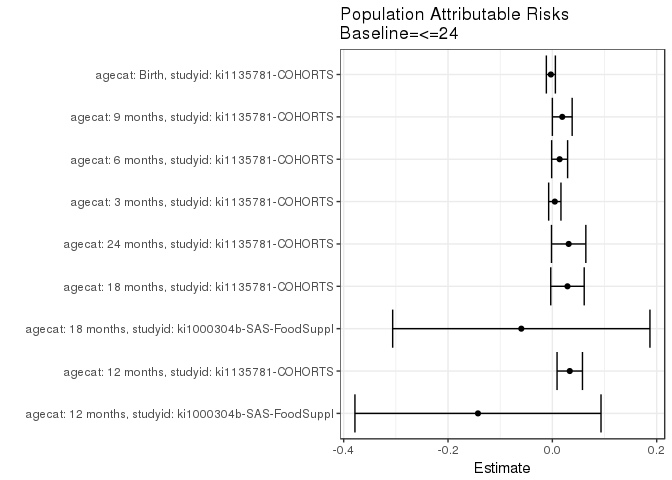

## Data Summary

| agecat | studyid | A | n | nA | nAY0 | nAY1 |
| --- | --- | --- | --- | --- | --- | --- |
| Birth | ki0047075b-MAL-ED | <=24 | 607 | 11 | 11 | 0 |
| Birth | ki0047075b-MAL-ED | (24-28] | 607 | 54 | 53 | 1 |
| Birth | ki0047075b-MAL-ED | (28-32] | 607 | 111 | 106 | 5 |
| Birth | ki0047075b-MAL-ED | >32 | 607 | 431 | 422 | 9 |
| Birth | ki1000304b-SAS-FoodSuppl | <=24 | 0 | 0 | 0 | 0 |
| Birth | ki1000304b-SAS-FoodSuppl | (24-28] | 0 | 0 | 0 | 0 |
| Birth | ki1000304b-SAS-FoodSuppl | (28-32] | 0 | 0 | 0 | 0 |
| Birth | ki1000304b-SAS-FoodSuppl | >32 | 0 | 0 | 0 | 0 |
| Birth | ki1135781-COHORTS | <=24 | 3334 | 869 | 854 | 15 |
| Birth | ki1135781-COHORTS | (24-28] | 3334 | 829 | 820 | 9 |
| Birth | ki1135781-COHORTS | (28-32] | 3334 | 700 | 691 | 9 |
| Birth | ki1135781-COHORTS | >32 | 3334 | 936 | 921 | 15 |
| Birth | ki1148112-LCNI-5 | <=24 | 0 | 0 | 0 | 0 |
| Birth | ki1148112-LCNI-5 | (24-28] | 0 | 0 | 0 | 0 |
| Birth | ki1148112-LCNI-5 | (28-32] | 0 | 0 | 0 | 0 |
| Birth | ki1148112-LCNI-5 | >32 | 0 | 0 | 0 | 0 |
| 3 months | ki0047075b-MAL-ED | <=24 | 744 | 14 | 14 | 0 |
| 3 months | ki0047075b-MAL-ED | (24-28] | 744 | 63 | 62 | 1 |
| 3 months | ki0047075b-MAL-ED | (28-32] | 744 | 143 | 135 | 8 |
| 3 months | ki0047075b-MAL-ED | >32 | 744 | 524 | 514 | 10 |
| 3 months | ki1000304b-SAS-FoodSuppl | <=24 | 97 | 17 | 15 | 2 |
| 3 months | ki1000304b-SAS-FoodSuppl | (24-28] | 97 | 27 | 24 | 3 |
| 3 months | ki1000304b-SAS-FoodSuppl | (28-32] | 97 | 24 | 20 | 4 |
| 3 months | ki1000304b-SAS-FoodSuppl | >32 | 97 | 29 | 25 | 4 |
| 3 months | ki1135781-COHORTS | <=24 | 3240 | 820 | 795 | 25 |
| 3 months | ki1135781-COHORTS | (24-28] | 3240 | 795 | 774 | 21 |
| 3 months | ki1135781-COHORTS | (28-32] | 3240 | 678 | 665 | 13 |
| 3 months | ki1135781-COHORTS | >32 | 3240 | 947 | 892 | 55 |
| 3 months | ki1148112-LCNI-5 | <=24 | 0 | 0 | 0 | 0 |
| 3 months | ki1148112-LCNI-5 | (24-28] | 0 | 0 | 0 | 0 |

[output cut: 82 more lines]

## Results Table

### Parameter: TSM

| agecat | studyid | intervention_level | baseline_level | estimate | ci_lower | ci_upper |
| --- | --- | --- | --- | --- | --- | --- |
| Birth | ki1135781-COHORTS | <=24 | NA | 0.0172612 | 0.0086004 | 0.0259220 |
| Birth | ki1135781-COHORTS | (24-28] | NA | 0.0108565 | 0.0038012 | 0.0179117 |
| Birth | ki1135781-COHORTS | (28-32] | NA | 0.0128571 | 0.0045102 | 0.0212041 |
| Birth | ki1135781-COHORTS | >32 | NA | 0.0160256 | 0.0079797 | 0.0240715 |
| 3 months | ki1135781-COHORTS | <=24 | NA | 0.0304878 | 0.0187186 | 0.0422570 |
| 3 months | ki1135781-COHORTS | (24-28] | NA | 0.0264151 | 0.0152659 | 0.0375643 |
| 3 months | ki1135781-COHORTS | (28-32] | NA | 0.0191740 | 0.0088499 | 0.0294982 |
| 3 months | ki1135781-COHORTS | >32 | NA | 0.0580781 | 0.0431793 | 0.0729770 |
| 6 months | ki1135781-COHORTS | <=24 | NA | 0.0499360 | 0.0346576 | 0.0652143 |
| 6 months | ki1135781-COHORTS | (24-28] | NA | 0.0390836 | 0.0251373 | 0.0530298 |
| 6 months | ki1135781-COHORTS | (28-32] | NA | 0.0592824 | 0.0409979 | 0.0775668 |
| 6 months | ki1135781-COHORTS | >32 | NA | 0.0994475 | 0.0799470 | 0.1189480 |
| 9 months | ki1135781-COHORTS | <=24 | NA | 0.0792839 | 0.0603443 | 0.0982235 |
| 9 months | ki1135781-COHORTS | (24-28] | NA | 0.0732357 | 0.0546000 | 0.0918714 |
| 9 months | ki1135781-COHORTS | (28-32] | NA | 0.0893417 | 0.0672050 | 0.1114784 |
| 9 months | ki1135781-COHORTS | >32 | NA | 0.1423767 | 0.1194414 | 0.1653120 |
| 12 months | ki1000304b-SAS-FoodSuppl | <=24 | NA | 0.5882353 | 0.3530030 | 0.8234676 |
| 12 months | ki1000304b-SAS-FoodSuppl | (24-28] | NA | 0.4800000 | 0.2830874 | 0.6769126 |
| 12 months | ki1000304b-SAS-FoodSuppl | (28-32] | NA | 0.4090909 | 0.2025147 | 0.6156671 |
| 12 months | ki1000304b-SAS-FoodSuppl | >32 | NA | 0.3571429 | 0.1786912 | 0.5355945 |
| 12 months | ki1135781-COHORTS | <=24 | NA | 0.1347424 | 0.1104149 | 0.1590699 |
| 12 months | ki1135781-COHORTS | (24-28] | NA | 0.1540541 | 0.1280398 | 0.1800684 |
| 12 months | ki1135781-COHORTS | (28-32] | NA | 0.1549521 | 0.1266008 | 0.1833033 |
| 12 months | ki1135781-COHORTS | >32 | NA | 0.2172452 | 0.1901943 | 0.2442962 |
| 18 months | ki1000304b-SAS-FoodSuppl | <=24 | NA | 0.5000000 | 0.2535330 | 0.7464670 |
| 18 months | ki1000304b-SAS-FoodSuppl | (24-28] | NA | 0.4166667 | 0.2182419 | 0.6150914 |
| 18 months | ki1000304b-SAS-FoodSuppl | (28-32] | NA | 0.4090909 | 0.2024066 | 0.6157753 |
| 18 months | ki1000304b-SAS-FoodSuppl | >32 | NA | 0.4545455 | 0.2452281 | 0.6638628 |
| 18 months | ki1135781-COHORTS | <=24 | NA | 0.2590529 | 0.2270013 | 0.2911046 |
| 18 months | ki1135781-COHORTS | (24-28] | NA | 0.2713068 | 0.2384564 | 0.3041573 |
| 18 months | ki1135781-COHORTS | (28-32] | NA | 0.2871622 | 0.2507100 | 0.3236143 |
| 18 months | ki1135781-COHORTS | >32 | NA | 0.3284493 | 0.2962789 | 0.3606197 |
| 24 months | ki1135781-COHORTS | <=24 | NA | 0.2890411 | 0.2561510 | 0.3219311 |
| 24 months | ki1135781-COHORTS | (24-28] | NA | 0.3000000 | 0.2660465 | 0.3339535 |
| 24 months | ki1135781-COHORTS | (28-32] | NA | 0.3225256 | 0.2846723 | 0.3603789 |
| 24 months | ki1135781-COHORTS | >32 | NA | 0.3623529 | 0.3300330 | 0.3946729 |

### Parameter: E(Y)

| agecat | studyid | intervention_level | baseline_level | estimate | ci_lower | ci_upper |
| --- | --- | --- | --- | --- | --- | --- |
| Birth | ki1135781-COHORTS | NA | NA | 0.0143971 | 0.0143106 | 0.0144837 |
| 3 months | ki1135781-COHORTS | NA | NA | 0.0351852 | 0.0346614 | 0.0357089 |
| 6 months | ki1135781-COHORTS | NA | NA | 0.0638645 | 0.0630155 | 0.0647134 |
| 9 months | ki1135781-COHORTS | NA | NA | 0.0982697 | 0.0972500 | 0.0992894 |
| 12 months | ki1000304b-SAS-FoodSuppl | NA | NA | 0.4456522 | 0.4287331 | 0.4625713 |
| 12 months | ki1135781-COHORTS | NA | NA | 0.1681034 | 0.1669311 | 0.1692758 |
| 18 months | ki1000304b-SAS-FoodSuppl | NA | NA | 0.4404762 | 0.4331912 | 0.4477612 |
| 18 months | ki1135781-COHORTS | NA | NA | 0.2880339 | 0.2870221 | 0.2890457 |
| 24 months | ki1135781-COHORTS | NA | NA | 0.3203070 | 0.3192239 | 0.3213902 |

### Parameter: RR

| agecat | studyid | intervention_level | baseline_level | estimate | ci_lower | ci_upper |
| --- | --- | --- | --- | --- | --- | --- |
| Birth | ki1135781-COHORTS | (24-28] | <=24 | 0.6289505 | 0.2767273 | 1.429489 |
| Birth | ki1135781-COHORTS | (28-32] | <=24 | 0.7448571 | 0.3278948 | 1.692043 |
| Birth | ki1135781-COHORTS | >32 | <=24 | 0.9284188 | 0.4565414 | 1.888025 |
| 3 months | ki1135781-COHORTS | (24-28] | <=24 | 0.8664151 | 0.4890071 | 1.535101 |
| 3 months | ki1135781-COHORTS | (28-32] | <=24 | 0.6289086 | 0.3242323 | 1.219884 |
| 3 months | ki1135781-COHORTS | >32 | <=24 | 1.9049630 | 1.1983756 | 3.028169 |
| 6 months | ki1135781-COHORTS | (24-28] | <=24 | 0.7826735 | 0.4891523 | 1.252325 |
| 6 months | ki1135781-COHORTS | (28-32] | <=24 | 1.1871675 | 0.7688404 | 1.833107 |
| 6 months | ki1135781-COHORTS | >32 | <=24 | 1.9915002 | 1.3847028 | 2.864205 |
| 9 months | ki1135781-COHORTS | (24-28] | <=24 | 0.9237146 | 0.6515679 | 1.309531 |
| 9 months | ki1135781-COHORTS | (28-32] | <=24 | 1.1268581 | 0.7987204 | 1.589804 |
| 9 months | ki1135781-COHORTS | >32 | <=24 | 1.7957833 | 1.3462437 | 2.395434 |
| 12 months | ki1000304b-SAS-FoodSuppl | (24-28] | <=24 | 0.8160000 | 0.4601348 | 1.447089 |
| 12 months | ki1000304b-SAS-FoodSuppl | (28-32] | <=24 | 0.6954545 | 0.3651962 | 1.324376 |
| 12 months | ki1000304b-SAS-FoodSuppl | >32 | <=24 | 0.6071429 | 0.3201467 | 1.151417 |
| 12 months | ki1135781-COHORTS | (24-28] | <=24 | 1.1433227 | 0.8929082 | 1.463966 |
| 12 months | ki1135781-COHORTS | (28-32] | <=24 | 1.1499875 | 0.8893191 | 1.487060 |
| 12 months | ki1135781-COHORTS | >32 | <=24 | 1.6123005 | 1.2947785 | 2.007689 |
| 18 months | ki1000304b-SAS-FoodSuppl | (24-28] | <=24 | 0.8333333 | 0.4199085 | 1.653799 |
| 18 months | ki1000304b-SAS-FoodSuppl | (28-32] | <=24 | 0.8181818 | 0.4039228 | 1.657301 |
| 18 months | ki1000304b-SAS-FoodSuppl | >32 | <=24 | 0.9090909 | 0.4630693 | 1.784714 |
| 18 months | ki1135781-COHORTS | (24-28] | <=24 | 1.0473027 | 0.8808236 | 1.245247 |
| 18 months | ki1135781-COHORTS | (28-32] | <=24 | 1.1085077 | 0.9284423 | 1.323496 |
| 18 months | ki1135781-COHORTS | >32 | <=24 | 1.2678850 | 1.0827971 | 1.484611 |
| 24 months | ki1135781-COHORTS | (24-28] | <=24 | 1.0379147 | 0.8840179 | 1.218603 |
| 24 months | ki1135781-COHORTS | (28-32] | <=24 | 1.1158469 | 0.9475671 | 1.314012 |
| 24 months | ki1135781-COHORTS | >32 | <=24 | 1.2536381 | 1.0848786 | 1.448649 |

### Parameter: PAR

| agecat | studyid | intervention_level | baseline_level | estimate | ci_lower | ci_upper |
| --- | --- | --- | --- | --- | --- | --- |
| Birth | ki1135781-COHORTS | <=24 | NA | -0.0028641 | -0.0115253 | 0.0057971 |
| 3 months | ki1135781-COHORTS | <=24 | NA | 0.0046974 | -0.0070835 | 0.0164783 |
| 6 months | ki1135781-COHORTS | <=24 | NA | 0.0139285 | -0.0013734 | 0.0292304 |
| 9 months | ki1135781-COHORTS | <=24 | NA | 0.0189858 | 0.0000187 | 0.0379528 |
| 12 months | ki1000304b-SAS-FoodSuppl | <=24 | NA | -0.1425831 | -0.3784231 | 0.0932568 |
| 12 months | ki1135781-COHORTS | <=24 | NA | 0.0333610 | 0.0090053 | 0.0577167 |
| 18 months | ki1000304b-SAS-FoodSuppl | <=24 | NA | -0.0595238 | -0.3060984 | 0.1870508 |
| 18 months | ki1135781-COHORTS | <=24 | NA | 0.0289810 | -0.0030867 | 0.0610486 |
| 24 months | ki1135781-COHORTS | <=24 | NA | 0.0312660 | -0.0016419 | 0.0641738 |

### Parameter: PAF

| agecat | studyid | intervention_level | baseline_level | estimate | ci_lower | ci_upper |
| --- | --- | --- | --- | --- | --- | --- |
| Birth | ki1135781-COHORTS | <=24 | NA | -0.1989356 | -0.9802424 | 0.2741058 |
| 3 months | ki1135781-COHORTS | <=24 | NA | 0.1335045 | -0.2750930 | 0.4111689 |
| 6 months | ki1135781-COHORTS | <=24 | NA | 0.2180943 | -0.0620769 | 0.4243576 |
| 9 months | ki1135781-COHORTS | <=24 | NA | 0.1932008 | -0.0247290 | 0.3647834 |
| 12 months | ki1000304b-SAS-FoodSuppl | <=24 | NA | -0.3199426 | -0.9724595 | 0.1167127 |
| 12 months | ki1135781-COHORTS | <=24 | NA | 0.1984554 | 0.0397216 | 0.3309506 |
| 18 months | ki1000304b-SAS-FoodSuppl | <=24 | NA | -0.1351351 | -0.8588593 | 0.3068158 |
| 18 months | ki1135781-COHORTS | <=24 | NA | 0.1006165 | -0.0178885 | 0.2053249 |
| 24 months | ki1135781-COHORTS | <=24 | NA | 0.0976124 | -0.0111914 | 0.1947090 |